[figure not shown]

# Tecnológico Nacional de México campus Colima

## Cómo funciona un algoritmo genético

#### Como su propio nombre indica, los algoritmos genéticos se llaman así porque simulan el comportamiento que se da en la naturaleza, al igua que a las redes neuronales se les llama así por su similitud con las neuronas.

#### Más concretamente, cada candidato a solución, en los algoritmos genéticos recibe el nombre de individuo. Por su parte, el genotipo,genoma o cromosoma denota la estructura de datos presente en un individuo. Un gen es una posición dentro de dicha estructura de datos y, el dato concreto, recibe el nombre de alelo.

#### Así pues, partimos de una serie de individuos, cada uno con unos alelos (dat0s) diferentes. Como es lógico, no todos los individuos serán igual de buenos a la hora de optimizar nuestro objetivo (al igual que no todos los primeros humanos estaban igual de bien adaptados a su entorno). Por tanto, cada individuo se evalua con una función, llamada fenotipo o fitness.

#### Una vez calculado el fitness de cada individuo, se realizará un proceso de selección de individuo (más adelante entramos más en detalle en este apartado). La idea es sencilla, nos quedaremos con aquellos individuos que mejor fitness tengan.

#### Una vez se haya hecho la selección de individuos, los individuos se juntarán entre ellos para obtener desdendencia, es decir, generar nuevos individuos. Este proceso se conoce como breeding (crianza) y la generación de nuevos individuos surge mediante los operadores genéticos, como son el crossover y la mutation.

## Cómo realizar la selección de individuos

#### 1.- Método de la ruleta: consiste en que la probabilizad de breeding sea proporcional al fitness, es decir, que cuanto mejor sea tu fitness, más probable es que seas elegido. La forma de calcular la probabilidad del individuo se da dividiendo su fitness entre la suma total de fitness lograda.

#### 2.- Ranking: aunque el método de la ruleta parezca sólido, el problema se da cuando muchos individuos tienen probabilidades parecidas. En estos casos, es posible que no se coja al mejor individuo. Así pues, el método de ranking consiste en ordenar a los individuos en base al fitness, de tal forma que se elijan los N indivudios que mejor fitness hayan tenido.

#### 3.- Selección de estado estacionario: consiste en eliminar una serie de individuos con mal fitness y que estos sean reemplazados por la crianza a partir de los individuos con mejores fitness.

#### 4.- Selección basada en torneo: se crean parejas de forma aleatoria y de cada pareja se seleccionará aquel que tenga mejor fitness.

#### 5.- Elitismo: se basa en realizar reproducciones parciales, es decir, que los individuos con mejor fitness tengan una descendencia que sea exactamente igual que ellos.

## Cómo obtener nuevos individuos mediante crossover

#### 1.- Cruce de un punto: consiste en partir en dos los alelos de los padres. El hijo se llevará la un trozo de los alelos de un padre y el otro trozo del otro padre.

#### 2.- Cruce de varios puntos: sigue la misma idea del punto anterior, solo que ahora los alelos se parten en 3 o más grupos y el hijo se compondrá de combinaciones de dichas partes.

#### 3.- Cruce uniforme: cada alelo se elegirá de uno de los padres de forma aleatoria, creando al hijo como una selección aleatorio de los valores de los padres.

#### 4.- Crossover the listas ordenadas: este sistema de crossover se utiliza cuando no todos los chromosomas son soluciones válidas y básicamente permite añadir una serie de condiciones al crossover.

## Cómo obtener nuevos individuos mediante mutación

#### 1.- Mutacion aleatoria: consiste en mutar, de forma aleatoria, un alelo (un valor).

#### 2.- Shrink: consiste en sumar un valor aleatorio de una distribución normal (u otro tipo de distribución, como una distribución uniforme), a uno de los valores del individuo.

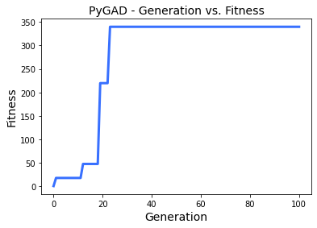

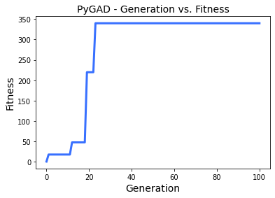

```python
import pygad
import numpy

inputs = [0.4,1,0,7,8]
desired_output = 32

def fitness_func(solution, solution_idx):
    output = numpy.sum(solution*inputs)
    fitness = 1.0 / (numpy.abs(output - desired_output) + 0.000001)

    return fitness

ga_instance = pygad.GA(num_generations=100,
                       sol_per_pop=10,
                       num_genes=len(inputs),
                       num_parents_mating=2,
                       fitness_func=fitness_func,
                       mutation_type="random",
                       mutation_probability=0.6)

ga_instance.run()

ga_instance.plot_fitness()
```

## Carga de Datos

#### Lo primero de todo que tenemos que hacer es obtener unos datos. Para ello, usaremos el dataset load_breast_cancer ofrecido por sklearn. Además, vamos a visualizar las primeras observaciones, por si no estás familiarizado con el dataset:

```python
from sklearn.datasets import load_breast_cancer

diabetes = load_breast_cancer(as_frame = True)
data = diabetes['data']
target = diabetes['target']

data.head()
```

|  | mean radius | mean texture | mean perimeter | mean area | mean smoothness | mean compactness | mean concavity | mean concave points | mean symmetry | mean fractal dimension | ... | worst radius | worst texture | worst perimeter | worst area | worst smoothness | worst compactness | worst concavity | worst concave points | worst symmetry | worst fractal dimension |
| --- | --- | --- | --- | --- | --- | --- | --- | --- | --- | --- | --- | --- | --- | --- | --- | --- | --- | --- | --- | --- | --- |
| 0 | 17.99 | 10.38 | 122.80 | 1001.0 | 0.11840 | 0.27760 | 0.3001 | 0.14710 | 0.2419 | 0.07871 | ... | 25.38 | 17.33 | 184.60 | 2019.0 | 0.1622 | 0.6656 | 0.7119 | 0.2654 | 0.4601 | 0.11890 |
| 1 | 20.57 | 17.77 | 132.90 | 1326.0 | 0.08474 | 0.07864 | 0.0869 | 0.07017 | 0.1812 | 0.05667 | ... | 24.99 | 23.41 | 158.80 | 1956.0 | 0.1238 | 0.1866 | 0.2416 | 0.1860 | 0.2750 | 0.08902 |
| 2 | 19.69 | 21.25 | 130.00 | 1203.0 | 0.10960 | 0.15990 | 0.1974 | 0.12790 | 0.2069 | 0.05999 | ... | 23.57 | 25.53 | 152.50 | 1709.0 | 0.1444 | 0.4245 | 0.4504 | 0.2430 | 0.3613 | 0.08758 |
| 3 | 11.42 | 20.38 | 77.58 | 386.1 | 0.14250 | 0.28390 | 0.2414 | 0.10520 | 0.2597 | 0.09744 | ... | 14.91 | 26.50 | 98.87 | 567.7 | 0.2098 | 0.8663 | 0.6869 | 0.2575 | 0.6638 | 0.17300 |
| 4 | 20.29 | 14.34 | 135.10 | 1297.0 | 0.10030 | 0.13280 | 0.1980 | 0.10430 | 0.1809 | 0.05883 | ... | 22.54 | 16.67 | 152.20 | 1575.0 | 0.1374 | 0.2050 | 0.4000 | 0.1625 | 0.2364 | 0.07678 |

5 rows × 30 columns

```python
#Ahora que tenemos los datos cargados, vamos a separarlos entre train y test, usando la función train_test_split ofrecida por sklearn
from sklearn.model_selection import train_test_split

seed = 1234
x_train, x_test, y_train, y_test = train_test_split(data, target, random_state=seed)
```

## Creación de la red neuronal

```python
from keras.models import Sequential
from keras.layers import Dense, Input

model = Sequential()
model.add(Input(x_train.shape[1]))
model.add(Dense(8, activation = 'relu'))
model.add(Dense(1, activation = 'sigmoid'))
```

## Optimización de red neuronal con algoritmo genético

#### Ahora que tenemos el modelo creado, es cuando entra en acción la ejecución del modelo usando el algoritmo genético como optimizador del modelo. Para ello, los pasos son los siguientes: Crear un modelo optimizador en base a nuestro modelo optimizador. Dada la solución propuesta por el algoritmo genético, implementarla en nuestra red neuronal Hacer la predicción con el modelo y calcular el fitness de la predicción. Así pues, lo primero de todo es crear un algoritmo genético compatible con Keras. Para ello, la librería pygad cuenta con la función KerasGA. Esta función únicamente cuenta con dos parámetros: model: modelo de Keras que queremos que optimice. num_solutions: indica el número de soluciones a usar en la población. Cada una de estas soluciones contará con unos parámetros del modelo diferentes. Así pues, creamos el modelo optimizador.

```python
from pygad import kerasga

keras_ga = kerasga.KerasGA(
    model = model,
    num_solutions = 15
)
```

#### Hecho esto, podemos obtener los pesos propuestos por nuestro algoritmo genético mediante la función model_weights_as_matrix del módulo kerasga. Una vez tengamos los pesos, podremos aplicárselo a nuestro modelo mediante el método set_weights. Asimismo, aprovecharemos esta misma función para realizar las predicciones. Por último, vamos a calcular el fitness de las predicciones. En este sentido, es importante tener en cuenta una cosa, y es que la capacidad predictica de un modelo de clasificación se mide mediante la entropía. La entropía mide el «desorden» de nuestras predicciones, por lo que cuanto menor sea la entropía, mejor funciona el modelo. Sin embargo, nuestro algoritmo genético se basa en calcular el fitness del modelo. En este caso, cuanto mayor sea el fitness, mejor es el modelo. Así pues, vamos a invertir la entropía, de tal forma que maximizar el fitness implique reducir la entropía:

```python
from keras.losses import BinaryCrossentropy

def fitness_func(solution, solution_idx ):
  global model

  # Get the weights from the model
  weights = kerasga.model_weights_as_matrix(
      model= model,
      weights_vector= solution
      )

  # Set the weights
  model.set_weights(weights = weights)

  # Make the prediction
  prediction = model.predict(x_train)

  # Calculate fitness
  entropy = BinaryCrossentropy()(y_train, prediction)
  fitness = 1/(entropy.numpy() + 0.0001)

  return fitness
```

#### Con esto ya podríamos entrenar nuestra red neuronal con un algoritmo genético. Sin embargo, suele ser recomendable añadir un callback al proceso de aprendizaje, de tal forma que vayamos sabiendo qué tal va aprendiento nuestra red neuronal. La siguiente función es un ejemplo de un callback típico:

```python
fitness_evol = []

def callback_generation(ga_instance):
  global fitness_evol
  fitness_evol.append(ga_instance.best_solution()[1])
  generation = ga_instance.generations_completed

  if generation % 1 == 0:
    print(f"Generation {generation}. Fitness: {ga_instance.best_solution()[1]}")
```

```python
from pygad import GA

num_generations = 5
num_parents_mating = 5
initial_population = keras_ga.population_weights

ga_optimizer = GA(
    num_generations=num_generations,
    num_parents_mating=num_parents_mating,
    initial_population=initial_population,
    fitness_func=fitness_func,
    on_generation=callback_generation
    )

ga_optimizer.run()
```

```
Generation 1. Fitness: 0.17695719072074137
Generation 2. Fitness: 0.17818764532437414
Generation 3. Fitness: 0.17818764532437414
Generation 4. Fitness: 0.17818764532437414
Generation 5. Fitness: 0.17818764532437414
```

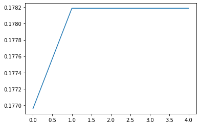

```python
#Con esto ya tendríamos nuestro modelo entrenado. Así pues, vamos a ver qué tal se ha ido comportando:

import seaborn as sns

sns.lineplot(
    x = range(len(fitness_evol)),
    y = fitness_evol
)
```

```python
#Por último, vamos a ver qué tal se comporta el nuestra red neuronal sobre datos nuevos:
from sklearn.metrics import confusion_matrix, auc
import numpy as np

pred = model.predict(x_test)
classes=np.argmax(pred,axis=1)
confusion_matrix(y_test, classes)
```

```
array([[55,  0],
       [88,  0]], dtype=int64)
```

## Problemas de optimización con algoritmos genéticos en Python

```python
margin = np.array([2, 2.5])
material_consumption = np.array([2,3])
material_max = 500

def fitness_func(solution, solution_idx):

  solution_added = solution + 50
  calculated_margin = np.sum(solution_added*margin)
  material_consumed = np.sum(solution_added*material_consumption)

  if material_consumed> material_max:
    return 0

  else:
    return calculated_margin

# Comprobamos con una posible solucion
print(f"Fitness for correct scenario: {fitness_func(np.array([0, 0]), '')}")
print(f"Fitness for incorrect scenario: {fitness_func(np.array([0, 1]), '')}")
```

```
Fitness for correct scenario: 225.0
Fitness for incorrect scenario: 227.5
```

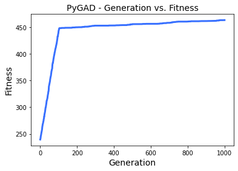

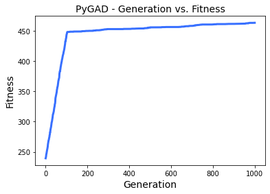

```python
#Ahora que tenemos nuestra función de fitness codificada, vamos a ejecutar nuestro algoritmo genético:

ga_instance = pygad.GA(num_generations=1000,
                       sol_per_pop=10,
                       num_genes=2,
                       num_parents_mating=2,
                       fitness_func=fitness_func,
                       mutation_type="random",
                       mutation_probability=0.6
                       )

ga_instance.run()

ga_instance.plot_fitness()
```

```python
#Por último, podemos comprobar cuál es la solución propuesta por nuestro algoritmo genético:

ga_instance.best_solution()[0] + 50
```

```
array([139.15415432,  73.85227098])
```

## Cómo programar un algoritmo genético desde cero en Python

#### Si queremos programar un algoritmo genético desde cero, tendremos que: Crear una población de n individuos. Codificar las diferentes maneras en las que se genera descendencia. Así pues, empezamos por lo primero: definir una población. Para ello, vamos a incluir una cuestión que considero ayuda bastante a la hora de converger, que consiste en definir una serie de límites que pueden recibir cada uno de los valores clave. Así pues, lo primero de todo creamos dicha población.

## Programar la creación de una población de un algoritmo genético

#### Para programar nuestro algoritmo genético en Python, usaremos una clase. Así pues, la creación de la población se hará en la inicialización de dicha clase. Dicho esto, para facilitar que el algoritmo converga de una forma más rápida, voy a crear dos tipos de inicialización de la población: Inicialización aleatoria de los alelos. Simplemente se crearán valores aleatorios que se deberán ir optimizando. Este tipo de inicialización se hará si el parámetro gene_limits es nulo. Inicialización limitada ed los alelos. Consiste en incluir unos límites para cada uno de nuestros alelos, de tal forma que lo valores se incialicen de forma aleatoria dentro de dichos límites. Este tipo de inicialización se hará si el parámetro gene_limits no es nulo. Dicho esto, programo la inicialización aleatoria de la población:

```python
import numpy as np


class GeneticAlgorithm:
  def __init__(self, n_variables, n_genes, random_state = None, gene_limits = None):

    self.n_variables = n_variables
    self.n_genes = n_genes
    self.gene_limits = gene_limits
    self.random_state = random_state

    # Create the population
    if self.gene_limits is not None:

      # Check that both vectors have the same length
      assert len(self.gene_limits) == self.n_variables

      limits = [np.random.uniform(limit[0], limit[1], self.n_genes)
        for limit in self.gene_limits]

    else:
      limits = [np.random.random(self.n_genes)
        for limit in range(self.n_variables)]

    # Convert list of limits to list of solutions
    self.population = list(zip(*limits))

ga = GeneticAlgorithm(
    n_variables = 2,
    n_genes = 10
)

ga.population
```

```
[(0.44977420539243884, 0.8677029555377144),
 (0.4593033605180309, 0.5622712534504752),
 (0.22684686172369795, 0.8538978979616205),
 (0.8731885256949953, 0.16061407818588747),
 (0.8788131430463203, 0.7563003061807754),
 (0.8265246822328798, 0.4502832022077782),
 (0.04791559184981076, 0.1859772148940585),
 (0.42831178781592083, 0.4271240115538687),
 (0.2357381157872459, 0.3065979356375479),
 (0.890602285995526, 0.8355308775919925)]
```

## Calcular el fitness del algoritmo genético

#### Partiendo de una población, tenemos que permitir a nuestro algoritmo genético recibir una función de fitness. Además, internamente usaremos dicha función de fitness para calcular el fitness de cada una de las soluciones. Así pues, ampliaremos el código anterior, incluyendo un nuevo parámetro fitness_func el cual recibe como input una solución y devuelve un valor de fitness. Asimismo, crearé un método llamado get_fitness_scores, que devuelva el fitness score de la solución actual. Esto facilitará el uso del fitness score a lo largo del algoritmo. Dicho esto, extendamos el código anterior incluyendo el fitness:

```python
import numpy as np
import inspect

class GeneticAlgorithm:
  def __init__(
      self, n_variables, n_genes, mutation_type = 'random', random_state = None,
      gene_limits = None, fitness_func = None):

    assert mutation_type in ['random']

    self.n_variables = n_variables
    self.n_genes = n_genes
    self.gene_limits = gene_limits
    self.mutation_type = mutation_type
    self.random_state = random_state
    self.fitness_func = fitness_func

    # Create the population
    if self.gene_limits is not None:

      # Check that both vectors have the same length
      assert len(self.gene_limits) == self.n_variables

      limits = [np.random.uniform(limit[0], limit[1], self.n_genes)
        for limit in self.gene_limits]

    else:
      limits = [np.random.random(self.n_genes)
        for limit in range(self.n_variables)]

    # Convert list of limits to list of solutions
    self.population = list(zip(*limits))

  def get_fitness_scores(self):
    scores = [self.fitness_func(ind) for ind in self.population]
    return np.array(scores)

def fitness_func(solution):
  solution = np.array(solution)
  solution_added = solution + 50
  calculated_margin = np.sum(solution_added*margin)
  material_consumed = np.sum(solution_added*material_consumption)

  if material_consumed> material_max:
    return 0

  else:
    return calculated_margin

ga = GeneticAlgorithm(
    n_variables = 2,
    n_genes = 10,
    fitness_func= fitness_func
)

fitness_scores = ga.get_fitness_scores()
fitness_scores
```

```
array([225.31853989, 227.85809976, 227.71173751, 226.60499542,
       228.07762987, 226.35587597, 228.67805434, 226.38969567,
       227.02434295, 227.46351247])
```

## Cómo programar la selección de individuos de un algoritmo genético

```python
def ranking_selection(scores, k):
    if k is None:
      raise ValueError('K must not be none if type ranking is selected.')

    ind = np.argpartition(scores, k)[-k:]

    return ind

def tournament_selection(scores, k, n_candidates):
  candidates = [np.random.randint(0, len(scores), 3) for i in range(3)]
  tournament_winner = [np.argmax(scores[tournament]) for i, tournament in enumerate(candidates)]
  ind = [tournament[tournament_winner[i]] for i, tournament in enumerate(candidates)]

  return np.array(ind)

def gene_selection(scores, type, k, n_candidates = None):

  if type not in ['ranking','tournament']:
    raise ValueError('Type should be ranking or tournament')

  if type == 'ranking':
    ind = ranking_selection(scores, k)
  elif type == 'tournament':
    ind = tournament_selection(scores, k, n_candidates)
  else:
    pass

  return ind


ranking_selection = gene_selection(scores= fitness_scores,
               type = 'ranking',
               k = 3
               )

tournament_selection = gene_selection(scores= fitness_scores,
               type = 'tournament',
               k = 3,
               n_candidates = 11
               )

print(f"""
Ranking selection results: {ranking_selection}
Tournament selection results: {tournament_selection}
""")
```

```
Ranking selection results: [1 2 4]
Tournament selection results: [9 2 6]
```

## Cómo programar la generación de descendencia

#### De cara a generar nuevas generaciones, vamos a permitir que nuestro modelo permita usar tanto el crossover como la mutación. Así pues, contaremos con otro parámetro (transformation_type) que nos indique el tipo de transformación a aplicar. Respecto al crossover, vamos a permitir dos tipos de crossovers: el crossover uniforme y el crossover en un punto. En cualquiera de los dos casos, es importante tener en cuenta que a partir de los dos padres se generarán dos nuevos hijos. Así pues, el número de parejas a generar deberá ser la mitad del total de individuos en la población.

```python
def crossover(parent1, parent2, crossover_type):

  # Check crossover type
  if crossover_type not in ['uniform', 'one_point']:
    raise ValueError('crossover_type should be one of uniform, one_point or multi_point')

  if crossover_type == 'one_point':
    index = np.random.choice(range(len(parent1)))
    children = [parent2[:index] + parent1[index:], parent1[:index] + parent2[index:]]

  elif crossover_type == 'uniform':
    parents = list(zip(*[parent1,parent2]))
    children1 = tuple([np.random.choice(element) for element in parents])
    children2 = tuple([np.random.choice(element) for element in parents])
    children = [children1, children2]
  else:
    pass

  return children

children_uniform = crossover(
    ga.population[0],
    ga.population[1],
    crossover_type = 'uniform'
    )

children_onepoint = crossover(
    ga.population[0],
    ga.population[1],
    crossover_type = 'one_point'
    )

print(f"""
Children Uniform: {children_uniform}
Children One Point: {children_onepoint}
""")
```

```
Children Uniform: [(0.07673920186081373, 0.06602459270709049), (0.07673920186081373, 0.06602459270709049)]
Children One Point: [(0.3527523050753819, 0.06602459270709049), (0.07673920186081373, 0.8610380601839314)]
```

```python
def mutation(individual, mutation_type):

  if mutation_type not in ['bitstring', 'shrink']:
    raise ValueError('mutation_type should be one of bitstring or shrinkg')

  # Get index of individual to modify
  index = np.random.choice(len(individual))

  # Convert individual to list so that can be modified
  individual_mod = list(individual)

  if mutation_type == 'bitstring':
    individual_mod[index] = 1 - individual_mod[index]

  else:
    individual_mod[index] = individual_mod[index] + np.random.rand()

  # Convert indivudal to tuple
  individual = tuple(individual_mod)

  return individual

mutation_bitstring = mutation(ga.population[0], mutation_type = 'bitstring')
mutation_shrink = mutation(ga.population[0], mutation_type = 'shrink')


print(f"""
Mutation bitstring: {mutation_bitstring}
Mutation shrink: {mutation_shrink}
""")
```

```
Mutation bitstring: (0.07673920186081373, 0.9339754072929095)
Mutation shrink: (1.04282006651066, 0.06602459270709049)
```

## Programar la evolución en los algoritmos genéticos

#### De cara a crear la evolución de nuestro algoritmo genético, simplemente debemos poner en conjunto todos los puntos anteriores, lo cual lo haré con el método optimize. En este sentido, he incluido ciertas cuestiones, relevantes, como el valor best_fitness_evolution el cual va guardando el mejor resultado de fitness de cada generación. Asimismo, también he creado un método, llamado view_fitness_evolution, el cual permite visualizar la evolución del mejor fitness obtenido, tal como hemos visto previamente con PyGAD. Así pues, el código final para generar un algoritmo genético en Python es el siguiente:

```python
import numpy as np
import inspect
from tqdm import tqdm
import matplotlib.pyplot as plt

class GeneticAlgorithm:
  def __init__(
      self,
      n_variables,
      n_genes,
      n_iterations,
      transformation_type = None,
      mutation_type = None,
      crossover_type = None,
      gene_selection_type = None,
      n_selected_individuals = None,
      n_candidates = None,
      random_state = None,
      gene_limits = None,
      fitness_func = None
      ):

    # Make validations
    if transformation_type not in ['mutation', 'transformation']:
      raise ValueError('transformation_type should be one of mutation or transformation.')

    self.n_variables = n_variables
    self.n_genes = n_genes
    self.gene_limits = gene_limits
    self.transformation_type = transformation_type
    self.mutation_type = mutation_type
    self.random_state = random_state
    self.fitness_func = fitness_func
    self.n_iterations = n_iterations
    self.gene_selection_type = gene_selection_type
    self.n_selected_individuals = n_selected_individuals
    self.n_candidates = n_candidates
    self.crossover_type = crossover_type
    self.best_fitness_evolution = []

    # Asserts
    # Check that fitness function is a function
    assert callable(fitness_func)

    # Create the population
    if self.gene_limits is not None:

      # Check that both vectors have the same length
      assert len(self.gene_limits) == self.n_variables

      limits = [np.random.uniform(limit[0], limit[1], self.n_genes)
        for limit in self.gene_limits]

    else:
      limits = [np.random.random(self.n_genes)
        for limit in range(self.n_variables)]

    # Convert list of limits to list of solutions
    self.population = np.array(list(zip(*limits)))

  def get_fitness_scores(self):
    scores = [self.fitness_func(ind) for ind in self.population]
    scores = np.array(scores)
    return scores

  def __append_best_score(self, scores):
    best_score = np.max(scores)
    self.best_fitness_evolution.append(best_score)
    return 'Ok'


  def __ranking_selection(self, k):
      if k is None:
        raise ValueError('K must not be none if type ranking is selected.')

      ind = np.argpartition(self.get_fitness_scores(), k)[-k:]
      return ind

  def __tournament_selection(self, k, n_candidates):
    candidates = [np.random.randint(0, len(self.get_fitness_scores()), 3) for i in range(3)]
    tournament_winner = [np.argmax(self.get_fitness_scores()[tournament]) for i, tournament in enumerate(candidates)]
    ind = [tournament[tournament_winner[i]] for i, tournament in enumerate(candidates)]

    return np.array(ind)

  def gene_selection(self, gene_selection_type, k, n_candidates = None):

    if gene_selection_type not in ['ranking','tournament']:
      raise ValueError('Type should be ranking or tournament')

    if gene_selection_type == 'ranking':
      ind = self.__ranking_selection(k)
    elif gene_selection_type == 'tournament':
      ind = self.__tournament_selection(k, n_candidates)
    else:
      pass

    return ind

  def __crossover(self, parent1, parent2, crossover_type):

    # Check crossover type
    if crossover_type not in ['uniform', 'one_point']:
      raise ValueError('crossover_type should be one of uniform, one_point or multi_point')

    if crossover_type == 'one_point':
      index = np.random.choice(range(len(parent1)))
      children = parent2[:index] + parent1[index:], parent1[:index] + parent2[index:]

    elif crossover_type == 'uniform':
      parents = list(zip(*[parent1,parent2]))
      children1 = tuple([np.random.choice(element) for element in parents])
      children2 = tuple([np.random.choice(element) for element in parents])
      children = children1, children2
    else:
      pass

    return children


  def __mutation(self, individual, mutation_type):

    if mutation_type not in ['bitstring', 'shrink']:
      raise ValueError('mutation_type should be one of bitstring or shrinkg')

    # Get index of individual to modify
    index = np.random.choice(len(individual))

    # Convert individual to list so that can be modified
    individual_mod = list(individual)

    if mutation_type == 'bitstring':
      individual_mod[index] = 1 - individual_mod[index]

    else:
      individual_mod[index] = individual_mod[index] + np.random.rand()

    # Convert indivudal to tuple
    individual = tuple(individual_mod)

    return individual

  def optimize(self):

    for i in tqdm(range(self.n_iterations)):

      # Calculate fitness score
      scores = self.get_fitness_scores()

      # Append best score
      _ = self.__append_best_score(scores)

      # Make Selection
      selected_genes = self.gene_selection(
          gene_selection_type = self.gene_selection_type,
          k = self.n_selected_individuals,
          n_candidates = self.n_candidates
          )

      # Get selected population
      selected_population = self.population[selected_genes.tolist()]


      # Make transformations (mutation/crossover)
      if self.transformation_type == 'mutation':
        transformed_genes_index = np.random.choice(
            range(len(selected_population)),
            self.n_genes
            )


        new_population = [self.__mutation(selected_population[i], self.mutation_type)
          for i in transformed_genes_index]

      else:
        # Get pairs of parents
        parents_pairs = np.random.choice(
            selected_genes,
            (int(self.n_genes/2),2)
            )

        # For each pair, make crossover
        new_population = [self.__crossover(self.population[parents[0]],
                                           self.population[parents[1]],
                                           crossover_type=self.crossover_type
                                           )
          for parents in parents_pairs]

        # Unnest population
        new_population = [child for children in new_population for child in children]

      # Set new population as population
      self.population = np.array(new_population)

    # When n_iterations are finished, fitness score
    scores = self.get_fitness_scores()

    # Append best score
    _ = self.__append_best_score(scores)

    # Get the result where the result is the best
    best_score_ind =np.argpartition(scores, 0)[0]

    best_solution = self.population[best_score_ind]

    return (best_solution, self.best_fitness_evolution[-1])

  def view_fitness_evolution(self):
    plt.plot(
        range(len(self.best_fitness_evolution)),
        self.best_fitness_evolution
    )
```

```
(array([14.62809696, 26.53305875]), 322.5680072808485)
```

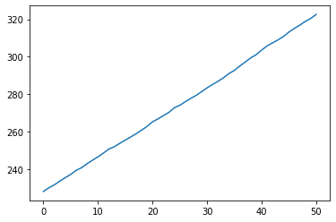

```python
#Por último vamos a probarlo, tanto aplicando mutation como aplicando crossover para ver qué resultados devuelve. Primero de todo, aplicamos mutation:
ga = GeneticAlgorithm(
  n_variables = 2,
  n_genes = 10,
  n_iterations = 50,
  transformation_type = 'mutation', #transformation
  mutation_type = 'shrink',
  #crossover_type = 'uniform',
  gene_selection_type = 'ranking',
  n_selected_individuals = 3,
  #n_candidates = None,
  #random_state = None,
  #gene_limits = None,
  fitness_func = fitness_func
  )

print(ga.optimize())
ga.view_fitness_evolution()
```

```
(array([0.79226383, 0.43045259]), 227.6606591206446)
```

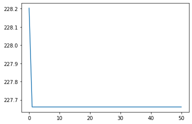

```python
#Por último aplicamos crossover:
ga = GeneticAlgorithm(
  n_variables = 2,
  n_genes = 10,
  n_iterations = 50,
  transformation_type = 'transformation',
  crossover_type = 'uniform',
  gene_selection_type = 'ranking',
  n_selected_individuals = 3,
  fitness_func = fitness_func
  )

print(ga.optimize())
ga.view_fitness_evolution()
```

## Conclusion

#### How has the development of this activity helped me to know the panorama of genetic algorithms? My conclusion for this activity is that genetics algorithms are a good way of solving problems where the main focus is to optimize a system, these kind of algorithms helps with the process of finding the best solution for any specific problem these are a more efficient way to find answers in comparison with other methods. In this activity we focus in developing a genetics algorithms by using python as our main software development tool.